# MIS 306 Data Analysis | Homework 2

# Objective

This project aims to analyze Boeing Company (`BA`) stock data from 2007 to 2025 using statistical and visualization techniques. Daily, weekly, and monthly return patterns were examined, along with comparisons across different periods and explorations of return distributions. Kolmogorov-Smirnov tests were applied to identify statistically significant differences, and various smoothing techniques, including LOESS, Polynomial Regression, and Generalized Additive Models (GAM), were used to highlight trends. Stock performance was visualized to uncover meaningful patterns and market behaviors.

# Data Transformation

## Looking for column names

```r
colnames(djdata)
```

```
##  [1] "MMM"  "AXP"  "AMGN" "AMZN" "AAPL" "BA"   "CAT"  "CVX"  "CSCO" "KO"
## [11] "DIS"  "GS"   "HD"   "HON"  "IBM"  "JNJ"  "JPM"  "MCD"  "MRK"  "MSFT"
## [21] "NKE"  "NVDA" "PG"   "CRM"  "SHW"  "TRV"  "UNH"  "VZ"   "V"    "WMT"
```

```r
colnames(djdata.df)
```

```
##  [1] "Date" "MMM"  "AXP"  "AMGN" "AMZN" "AAPL" "BA"   "CAT"  "CVX"  "CSCO"
## [11] "KO"   "DIS"  "GS"   "HD"   "HON"  "IBM"  "JNJ"  "JPM"  "MCD"  "MRK"
## [21] "MSFT" "NKE"  "NVDA" "PG"   "CRM"  "SHW"  "TRV"  "UNH"  "VZ"   "V"
## [31] "WMT"
```

## Removing IBM from data & Selecting BA from data

```r
symbols <- colnames(djdata)
symbols
```

```
##  [1] "MMM"  "AXP"  "AMGN" "AMZN" "AAPL" "BA"   "CAT"  "CVX"  "CSCO" "KO"
## [11] "DIS"  "GS"   "HD"   "HON"  "IBM"  "JNJ"  "JPM"  "MCD"  "MRK"  "MSFT"
## [21] "NKE"  "NVDA" "PG"   "CRM"  "SHW"  "TRV"  "UNH"  "VZ"   "V"    "WMT"
```

```r
symbols[-15]
```

```
##  [1] "MMM"  "AXP"  "AMGN" "AMZN" "AAPL" "BA"   "CAT"  "CVX"  "CSCO" "KO"
## [11] "DIS"  "GS"   "HD"   "HON"  "JNJ"  "JPM"  "MCD"  "MRK"  "MSFT" "NKE"
## [21] "NVDA" "PG"   "CRM"  "SHW"  "TRV"  "UNH"  "VZ"   "V"    "WMT"
```

```r
set.seed(20022025)
sample(symbols[-15], 16)
```

```
##  [1] "JNJ"  "MSFT" "BA"   "AXP"  "AAPL" "HD"   "DIS"  "MMM"  "UNH"  "NKE"
## [11] "AMGN" "MCD"  "TRV"  "VZ"   "GS"   "JPM"
```

```r
set.seed(20022025)
lst <- sample(symbols[-15], 16)

lst[3]
```

```
## [1] "BA"
```

```r
djdata[,lst[3]]
```

```
##                   BA
## 2007-01-03  64.40572
## 2007-01-04  64.66572
## 2007-01-05  64.39128
## 2007-01-08  64.23962
## 2007-01-09  63.56065
## 2007-01-10  64.47794
## 2007-01-11  64.16737
## 2007-01-12  63.65453
## 2007-01-16  63.56065
## 2007-01-17  64.16013
##        ...
## 2025-03-06 158.42999
## 2025-03-07 154.17999
## 2025-03-10 148.14999
## 2025-03-11 154.06000
## 2025-03-12 158.80000
## 2025-03-13 159.32001
## 2025-03-14 161.81000
## 2025-03-17 161.85001
## 2025-03-18 161.57001
## 2025-03-19 172.62000
```

```r
getSymbols(lst[3])
```

```
## [1] "BA"
```

From here we see that, according to the set seed our stock is `BA` (Boeing Company).

## Looking for the first and last few observations of data

```r
head(BA)
```

```
##            BA.Open BA.High BA.Low BA.Close BA.Volume BA.Adjusted
## 2007-01-03   88.90   90.30  88.45    89.17   4871700    64.40572
## 2007-01-04   88.34   89.83  87.01    89.53   2718900    64.66576
## 2007-01-05   89.78   90.00  88.50    89.15   3285900    64.39129
## 2007-01-08   88.61   89.41  87.56    88.94   2989000    64.23962
## 2007-01-09   88.93   89.71  87.56    88.00   4193800    63.56068
## 2007-01-10   88.04   89.34  88.00    89.27   3955200    64.47796
```

```r
tail(BA)
```

```
##            BA.Open BA.High BA.Low BA.Close BA.Volume BA.Adjusted
## 2025-03-28  177.75  178.50 172.45   173.31   8211100      173.31
## 2025-03-31  170.65  172.21 166.79   170.55   7477500      170.55
## 2025-04-01  170.00  170.98 164.22   168.17   8252800      168.17
## 2025-04-02  166.40  170.38 165.55   168.56   5826600      168.56
## 2025-04-03  160.00  160.21 150.41   150.91  15877400      150.91
## 2025-04-04  143.30  146.00 132.79   136.59  22254300      136.59
```

From head and tail of the data we can confirm that we imported data correctly.

# Visual Summaries

## Plot for opening, closing prices, high and low values and the volume

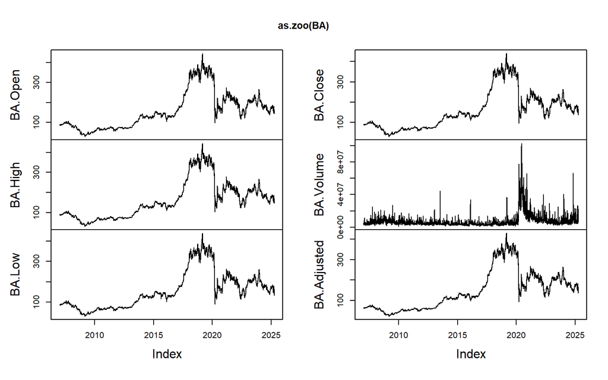

```r
plot(as.zoo(BA))
```

We see that the `BA.Open`, `BA.High`, `BA.Low`, and `BA.Close` graphs display stock prices at different points, with clear volatility and a big drop around 2020. The `BA.Volume` graph highlights trading activity, with noticeable spikes that likely indicate significant events or decisions made by investors. The BA.Adjusted graph shows the adjusted closing prices, which take dividends and stock splits into account, giving a more accurate picture of value.

## Line Chart (2007 - 2025)

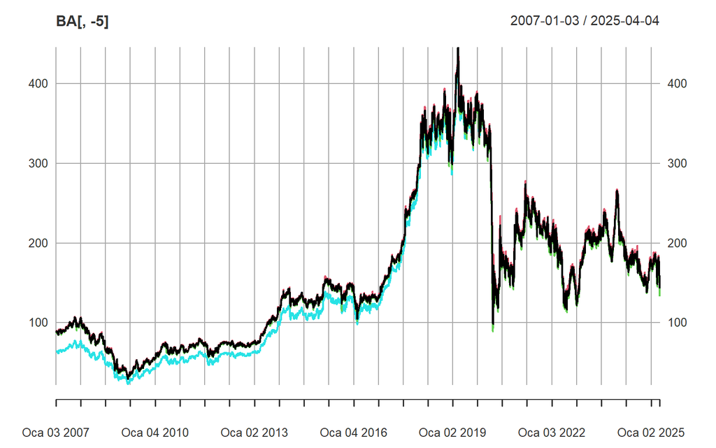

```r
plot(BA[,-5])
```

At this line graph we can see that it remains stable until 2016, followed by a sharp rise peaking in 2019. A sudden drop in 2020 that I assume its because of the pandemics. After 2021, the values fluctuate but stabilize at a lower level than the peak.

# Date and Time Analysis in Stock Returns

## Retrieving Weekday Data with and Without Labels

```r
# First few days without labelling.
head(wday(index(BA), label=F))
```

```
## [1] 4 5 6 2 3 4
```

```r
# First few days with labelling..
head(wday(index(BA), label=T))
```

```
## [1] Çar Per Cum Pzt Sal Çar
## Levels: Paz < Pzt < Sal < Çar < Per < Cum < Cmt
```

## Extracting and Converting Weekday Data

```r
# result is factor object..
str(head(wday(index(BA), label=T)))
```

```
##  Ord.factor w/ 7 levels "Paz"<"Pzt"<"Sal"<..: 4 5 6 2 3 4
```

```r
is.factor(head(wday(index(BA), label=T)))
```

```
## [1] TRUE
```

```r
# Get the first few days as character (instead of factor)
paste(head(wday(index(BA), label=T)))
```

```
## [1] "Çar" "Per" "Cum" "Pzt" "Sal" "Çar"
```

## Extracting Time-Based Features from Stock Data

```r
# days of year
yday(Sys.Date())
```

```
## [1] 95
```

```r
yday(index(first(BA["200303"], "1 week")))
```

```
## numeric(0)
```

```r
# days of quarter
qday(Sys.Date())
```

```
## [1] 5
```

```r
head(qday(index(BA)))
```

```
## [1]  3  4  5  8  9 10
```

```r
quarter(Sys.Date()) # quarter of the date
```

```
## [1] 2
```

```r
# days of month
head(mday(index(BA)))
```

```
## [1]  3  4  5  8  9 10
```

```r
# month of first few obs.
head(month(index(BA)))
```

```
## [1] 1 1 1 1 1 1
```

```r
# Convert to monthly data using to.monthly() function. Then get the first few months
head(month(index(to.monthly(BA)), label=T))
```

```
## [1] Oca Şub Mar Nis May Haz
## 12 Levels: Oca < Şub < Mar < Nis < May < Haz < Tem < Ağu < Eyl < ... < Ara
```

```r
# Just names only..
paste(head(month(index(to.monthly(BA)), label=T)))
```

```
## [1] "Oca" "Şub" "Mar" "Nis" "May" "Haz"
```

## Last Weekdays of Months

```r
# last weekdays of months and of course weekdaysdate
last_weekday_o_month <- function(dx) {
  ave(
  paste(wday(dx, label=T, abbr=F)),
  paste(month(dx, label=T, abbr = F)),
  FUN = function(x) tail(x[ !(x %in% c("Saturday","Sunday")) ], 1)
  )
}

last_weekdaydate_o_month <- function(dx){
  ave(
    dx,
# paste(month(dx, label=T, abbr = F)),
    month(dx, label=T),
    year(dx),
    FUN = function(x) tail(x[ !(wday(x, label=T, abbr=F) %in% c("Saturday","Sunday")) ], 1)
  )
}

# Get the last 25 end of months weekdays Adjusted close value..
Ad(BA[tail(unique(last_weekdaydate_o_month(index(BA))), 15),])
```

```
##            BA.Adjusted
## 2024-02-29      203.72
## 2024-03-28      192.99
## 2024-04-30      167.84
## 2024-05-31      177.61
## 2024-06-28      182.01
## 2024-07-31      190.60
## 2024-08-30      173.74
## 2024-09-30      152.04
## 2024-10-31      149.31
## 2024-11-29      155.44
## 2024-12-31      177.00
## 2025-01-31      176.52
## 2025-02-28      174.63
## 2025-03-31      170.55
## 2025-04-04      136.59
```

The price started at (`203.72`) in February 2024 but showed a downward trend over time. After a brief recovery in July 2024 (`190.60`), the stock declined again, reaching (`149.31`) in October. Although there was a slight increase at the end of 2024, the price dropped significantly in early 2025, hitting (`136.59`) in April. This suggests overall instability, with short-term recoveries but a general downward trend.

## Close, Adjusted Close, Day-of-week

```r
ba <- Ad(BA)

# Get Mondays
head(ba[wday(index(ba))==2])
```

```
##            BA.Adjusted
## 2007-01-08    64.23962
## 2007-01-22    61.82716
## 2007-01-29    61.75494
## 2007-02-05    65.52525
## 2007-02-12    64.67617
## 2007-02-26    64.48042
```

```r
# Mondays..
wday(head(ba[wday(index(ba))==2]), label=T)
```

```
## [1] Pzt Pzt Pzt Pzt Pzt Pzt
## Levels: Paz < Pzt < Sal < Çar < Per < Cum < Cmt
```

```r
# Fridays..
wday(head(ba[wday(index(ba))==6]), label=T)
```

```
## [1] Cum Cum Cum Cum Cum Cum
## Levels: Paz < Pzt < Sal < Çar < Per < Cum < Cmt
```

```r
# Get return series (cont. compounding, log(xt/xt-1)=log(xt)-log(xt-1))
ba.ret <- diff(log(ba))

# Mondays returns..
head(ba.ret[wday(index(ba.ret))==2])
```

```
##              BA.Adjusted
## 2007-01-08 -0.0023582580
## 2007-01-22 -0.0347851611
## 2007-01-29  0.0008186224
## 2007-02-05  0.0074127259
## 2007-02-12 -0.0089295645
## 2007-02-26 -0.0150665248
```

```r
# Data and return series together..
head(merge(ba, ba.ret))
```

```
##            BA.Adjusted BA.Adjusted.1
## 2007-01-03    64.40572            NA
## 2007-01-04    64.66576   0.004029405
## 2007-01-05    64.39129  -0.004253553
## 2007-01-08    64.23962  -0.002358258
## 2007-01-09    63.56068  -0.010625112
## 2007-01-10    64.47796   0.014328453
```

```r
# Head of mondays returns with levels.
head(merge(ba, ba.ret)[wday(merge(ba, ba.ret))==2])
```

```
##            BA.Adjusted BA.Adjusted.1
## 2007-01-08    64.23962 -0.0023582580
## 2007-01-22    61.82716 -0.0347851611
## 2007-01-29    61.75494  0.0008186224
## 2007-02-05    65.52525  0.0074127259
## 2007-02-12    64.67617 -0.0089295645
## 2007-02-26    64.48042 -0.0150665248
```

The data presents Boeing’s (`BA`) adjusted stock prices and their percentage changes over time, starting from January 2007. The (`BA.Adjusted`) column shows the stock’s adjusted closing prices, while (`BA.Adjusted`).1 represents the percentage change from the previous value.

From the table, we can observe fluctuations in stock prices. For example, on January 9, 2007, the price dropped by -1.06%, but on January 10, 2007, it increased by 1.43%. Similarly, in February 2007, the price first increased, then declined again. These ups and downs indicate short-term volatility in Boeing’s stock. The presence of negative values suggests periods of decline, while positive values show recoveries.

# Visual Summaries

## Histogram: BA returns

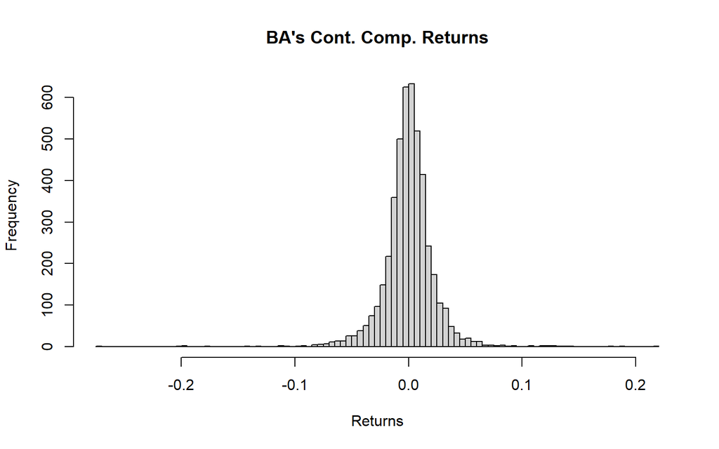

```r
hist(ba.ret, breaks=100, main="BA's Cont. Comp. Returns", xlab="Returns")
```

The distribution is bell-shaped indicating a normal-like distribution. Most returns are clustered near zero.

## Histogram for mondays returns

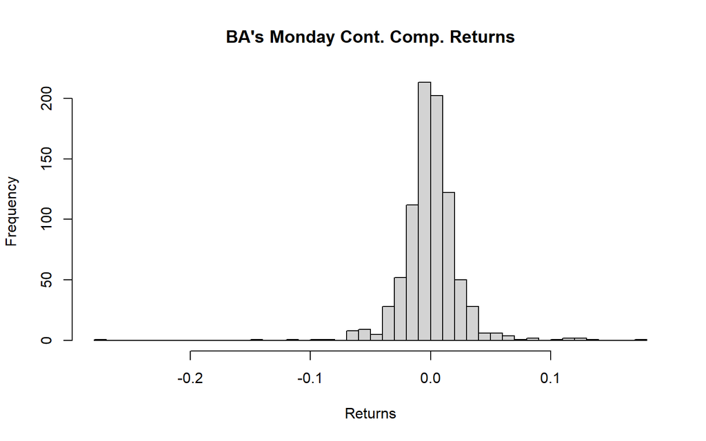

```r
hist(ba.ret[wday(index(ba.ret))==2], breaks=50, main="BA's Monday Cont. Comp. Returns", xlab="Returns")
```

We can the same thing here as well. The distribution is bell-shaped indicating a normal-like distribution. Most returns are clustered near zero.

## Histogram for fridays returns

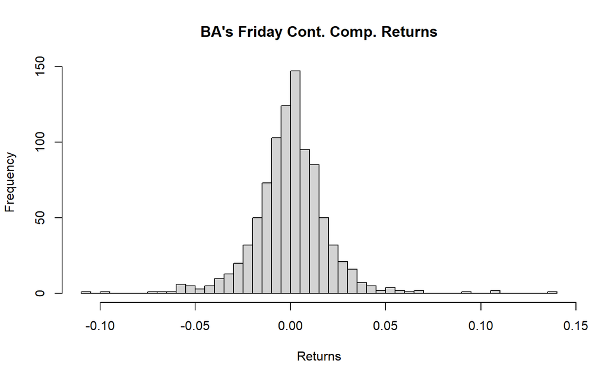

```r
hist(ba.ret[wday(index(ba.ret))==6], breaks=50, main="BA's Friday Cont. Comp. Returns", xlab="Returns")
```

We can see its very similar in this histogram too. The only difference I see is that this histogram has more observations on the negative side. The distribution is bell-shaped indicating a normal-like distribution. Most returns are clustered near zero.

## Empirical Cumulative Distribution of Fridays Return

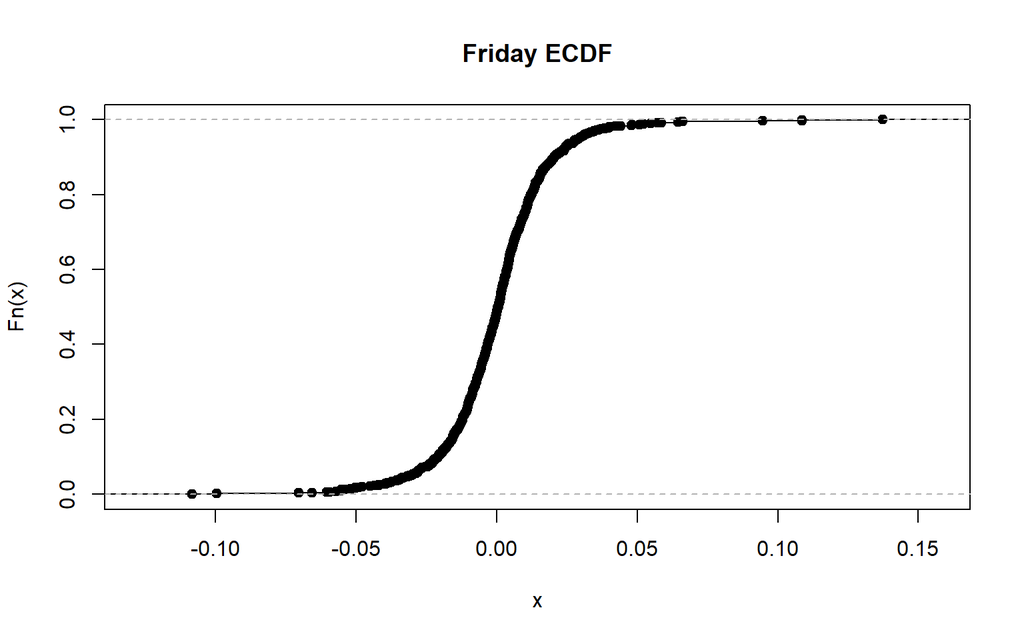

```r
plot(ecdf(as.vector(ba.ret[wday(index(ba.ret))==6])), main="Friday ECDF")
```

## Comparison of Empirical Cumulative Distributions of Monday (red) and Fridays (black) Return

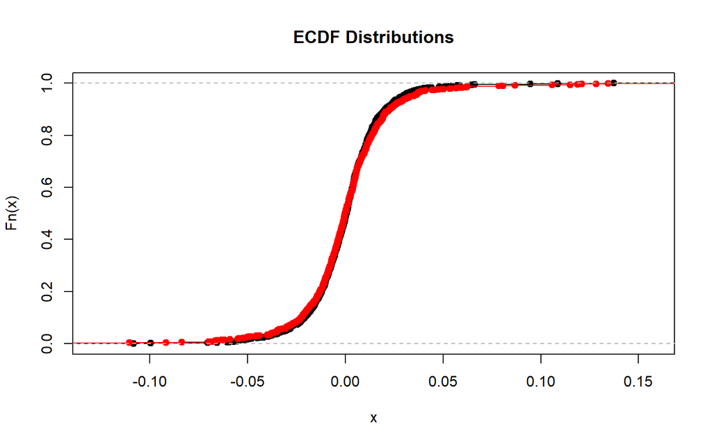

```r
plot(ecdf(as.vector(ba.ret[wday(index(ba.ret))==6])), main="ECDF Distributions")
lines(ecdf(as.vector(ba.ret[wday(index(ba.ret))==2])), col="red")
```

# Mean Returns

## Mean of the weekday returns

```r
# What about mean returns of weekdays..
mean.ret <- cbind(
mean(ba.ret[wday(index(ba.ret))==2], na.rm=T),
mean(ba.ret[wday(index(ba.ret))==3], na.rm=T),
mean(ba.ret[wday(index(ba.ret))==4], na.rm=T),
mean(ba.ret[wday(index(ba.ret))==5], na.rm=T),
mean(ba.ret[wday(index(ba.ret))==6], na.rm=T))
colnames(mean.ret) <- levels(wday(index(ba.ret), label=T))[2:6]
rownames(mean.ret) <- "Mean Returns"

# Lets see up to 6 digits..
round(mean.ret, 6)
```

```
##                   Pzt      Sal      Çar      Per      Cum
## Mean Returns 0.000188 0.000128 0.000146 0.000247 0.000112
```

Among these values, Thursday stands out with the highest mean return (`0.000247`), while Friday shows the lowest return (`0.000112`). This pattern might indicate that Thursday is generally a more profitable day for investments, while Friday could be associated with lower performance.

# BA Monday Prices Line Chart

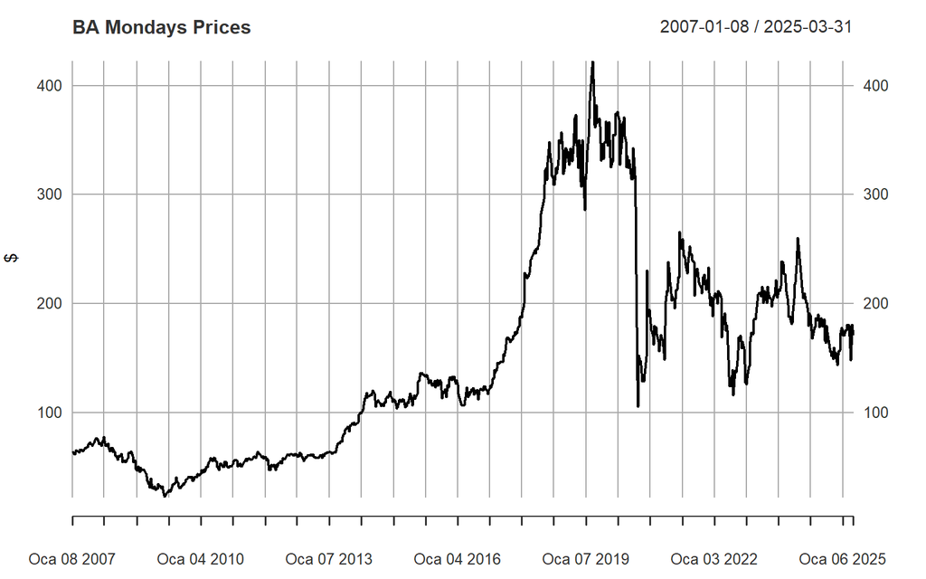

```r
plot(ba[wday(index(ba))==2], main="BA Mondays Prices", ylab="$")
```

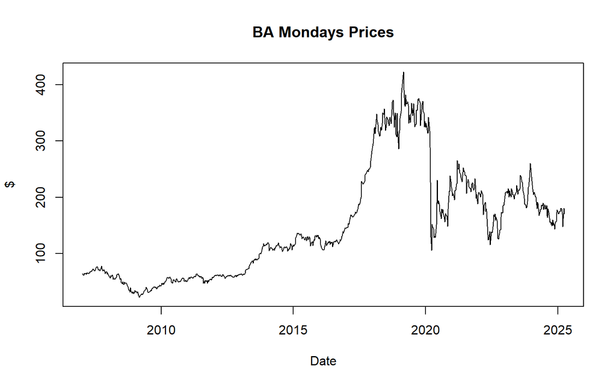

```r
# zoo type..
plot(as.zoo(ba[wday(index(ba))==2]), main="BA Mondays Prices", ylab="$", xlab="Date")
```

We see that before the 2017 it is increasing in its normal trend. Before 2017 its around 100 dollars. After 2017 prices increase exponentially and rises up to 400 dollars. After 2020 prices declines significantly. After 2021 it is increases around 200 dollars.